# R Notebook

```r
d <- read.csv('table.scn2a.vep_20190916.filtered.txt', sep='\t', na = 0)
```

이 데이터는 scn2a 유전자의 variant에 관한 data이다. 이 데이터에는 유전자의 variant가 표현형(단백질)에 미치는 효과를 측정한 다양한 column이 존재한다. 나는 이 column사이의 관련성이 있는지가 궁금해졌다. 또한 이들과 exon과의 관계도 궁금했다. 이로써 설계한 내 탐구주제는 크게 두가지이다.

**1. variant의 표현형에 대한 effect와 관련된 column간의 상관관계 유무 탐구**

**2. 1의 column들과 exon과의 관계 탐구**

# 1. data파악

#### 1-1. column 뜻 파악하기

우선 data의 column들을 살펴보고 무엇을 나타내는지 알아보았다. 아래는 내가 찾아본 일부 내용으로, 데이터 분석에 주로 쓰일 column들이다.

gnomAD_AF :Frequency of existing variant in gnomAD exomes combined population c.f) exon=진유전자

SIFT : SIFT prediction and/or score SIFT는 내성이 없는 아미노산 치환을 허용하지 않고 단백질의 아미노산 치환이 표현형 효과를 가지는지 아닌지를 예측하는 서열 상동성 기반 도구이다. SIFT는 단백질 진화가 단백질 기능과 상호 관련된다는 전제에 기반을 두고 있다. 중요하지 않은 위치는 배열에서 다양하게 보일 반면, 기능에 중요한 위치는 단백질 군의 정렬에서 보존되어야 한다.(-로 표시된 것 : 아미노산이 치환되지 않은것)

PolyPhen : PolyPhen prediction and/or score SNP/mutation 데이터베이스로써, PolyPhen-2 (Polymorphism Phenotyping v2)는 직접적인 물리적 및 비교 고려 사항을 사용하여 인간 단백질의 구조와 기능에 대한 아미노산 치환의 영향을 예측하는 도구이다. 아미노산의 치환이 얼마나 단백질 구조와 기능에 영향을 미치는가? 특정 아미노산의 치환이 얼마나 표현형(단백질)에 영향을 미치는가?

MPC :MPC score, kind of risk factor

# 2. SIFT, PolyPhen, MPC의 관계

#### 2-0. 데이터처리: ’-’처리 및 문자와 숫자 분리

variant가 아미노산서열을 바꾸지 못한 열의 경우 SIFT, PolyPhen, 그리고 MPC는 -값으로 표시가 되어있다. 이것은 값이 없는 것이므로 제외하였다. 또한 SIFT, polyphen은 그 impact의 정도를 카테고리화하여 나타내는 character 영역과 실제 측정값을 나타내는 numeric부분이 함께 존재한다. 이는 나중에 데이터를 처리할 때 불편하므로 둘을 분리하기로 했다: sift의 character부분은 sift_c로, numeric부분은 sift_n으로 분리하고 polyphen에도 똑같이 적용하였다. 이를 적용한 새로운 dataframe d1을 만들었다. 이 d1 dataframe을 앞으로 사용할 것이다.

```r
d1 <- d %>% filter(!SIFT == '-') %>% separate(SIFT, sep = '[)]', into = c('sift', 'rest'), remove=TRUE) %>% separate(sift, sep = '[(]', into = c('sift_c', 'sift_n'), remove=TRUE) %>% select(-rest) %>% separate(PolyPhen, sep = '[)]', into = c('polyphen', 'rest'), remove=TRUE) %>% separate(polyphen, sep = '[(]', into = c('poly_c', 'poly_n'), remove=TRUE) %>% select(-rest)


print(d1)
```

| Variant | Group | Gene | Feature | Consequence | cDNA_position | CDS_position | Protein_position | Amino_acids | Codons | IMPACT | VARIANT_CLASS | SYMBOL | BIOTYPE | SWISSPROT | sift_c | sift_n | poly_c | poly_n | EXON | DOMAINS | gnomAD_AF | MPC |
| --- | --- | --- | --- | --- | --- | --- | --- | --- | --- | --- | --- | --- | --- | --- | --- | --- | --- | --- | --- | --- | --- | --- |
| 2:166152337:G:A | gnomAD | ENSG00000136531 | ENST00000357398 | missense_variant | 294 | 4 | 2 | A/T | Gca/Aca | MODERATE | SNV | SCN2A | protein_coding | Q99250 | deleterious_low_confidence | 0 | possibly_damaging | 0.657 | 2/27 | - | 4.003e-06 | 1.70387829097 |
| 2:166152356:C:T | gnomAD | ENSG00000136531 | ENST00000357398 | missense_variant | 313 | 23 | 8 | P/L | cCg/cTg | MODERATE | SNV | SCN2A | protein_coding | Q99250 | deleterious_low_confidence | 0.03 | probably_damaging | 1 | 2/27 | - | 7.988e-06 | 1.97721070638 |
| 2:166152358:C:T | gnomAD | ENSG00000136531 | ENST00000357398 | missense_variant | 315 | 25 | 9 | P/S | Cca/Tca | MODERATE | SNV | SCN2A | protein_coding | Q99250 | deleterious | 0 | probably_damaging | 0.999 | 2/27 | - | 3.992e-06 | 1.96447962958 |
| 2:166152376:C:A | gnomAD | ENSG00000136531 | ENST00000357398 | missense_variant | 333 | 43 | 15 | R/S | Cgc/Agc | MODERATE | SNV | SCN2A | protein_coding | Q99250 | deleterious | 0.02 | benign | 0.165 | 2/27 | - | 3.988e-06 | 1.27784336031 |
| 2:166152376:C:T | gnomAD | ENSG00000136531 | ENST00000357398 | missense_variant | 333 | 43 | 15 | R/C | Cgc/Tgc | MODERATE | SNV | SCN2A | protein_coding | Q99250 | deleterious | 0.03 | benign | 0.007 | 2/27 | - | 3.988e-06 | 1.13048304163 |
| 2:166152377:G:A | gnomAD | ENSG00000136531 | ENST00000357398 | missense_variant | 334 | 44 | 15 | R/H | cGc/cAc | MODERATE | SNV | SCN2A | protein_coding | Q99250 | tolerated | 0.11 | benign | 0.007 | 2/27 | - | 3.988e-05 | 1.04054515853 |
| 2:166152380:T:G | gnomAD | ENSG00000136531 | ENST00000357398 | missense_variant | 337 | 47 | 16 | F/C | tTc/tGc | MODERATE | SNV | SCN2A | protein_coding | Q99250 | tolerated | 0.14 | possibly_damaging | 0.451 | 2/27 | - | 3.986e-06 | 1.69212223381 |
| 2:166152389:G:A | gnomAD | ENSG00000136531 | ENST00000357398 | missense_variant | 346 | 56 | 19 | R/K | aGg/aAg | MODERATE | SNV | SCN2A | protein_coding | Q99250 | tolerated | 0.61 | benign | 0.015 | 2/27 | - | 8.432e-02 | 0.855651613374 |
| 2:166152390:G:C | gnomAD | ENSG00000136531 | ENST00000357398 | missense_variant | 347 | 57 | 19 | R/S | agG/agC | MODERATE | SNV | SCN2A | protein_coding | Q99250 | tolerated | 0.08 | benign | 0.341 | 2/27 | - | 3.985e-06 | 1.23048034304 |
| 2:166152390:G:T | gnomAD | ENSG00000136531 | ENST00000357398 | missense_variant | 347 | 57 | 19 | R/S | agG/agT | MODERATE | SNV | SCN2A | protein_coding | Q99250 | tolerated | 0.08 | benign | 0.341 | 2/27 | - | NA | 1.23048034304 |

[output cut: 760 more lines]

#### 2-1. SIFT와 PolyPhen

우선 이 두개를 비교해보기로 했다. 두가지 column은 모두 단백질 아미노산의 치환과 그것이 표현형에 끼치는 영향력과 관련된 variant이다. 정의가 비슷하다. 이를 바탕으로 data를 확인하기에 앞서 아래와 같은 가설을 세웠다.

**sift는 값이 클수록 tolerate하고 polyphen은 값이 클수록 damaging하다. 그리고 둘은 정의가 유사하므로 서로 연관성을 띌 것이며, 이는 기울기가 감소하는 그래프로 나타날 것이다.**

데이터를 확인해보았다.

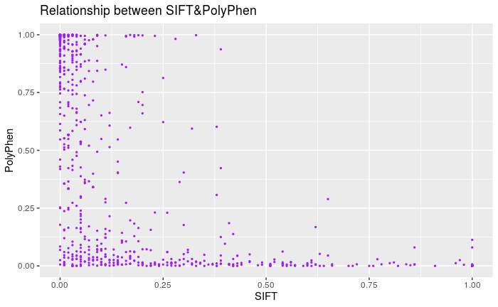

```r
d1 %>% ggplot(aes(as.numeric(sift_n), as.numeric(poly_n))) + geom_point(size = 0.5, col = 'purple') + labs(x='SIFT', y='PolyPhen', title = 'Relationship between SIFT&PolyPhen')
```

이 그래프는 명확한 결과를 보여주진 않지만, 가설대로 polyphen과 sift의 수치가 반비례관계처럼 보인다.

아래의 코드로 표의 형식으로도 살펴보았다.

```r
d1 %>% group_by(sift_c) %>% count(poly_c)
```

| sift_c | poly_c | n |
| --- | --- | --- |
| deleterious | benign | 66 |
| deleterious | possibly_damaging | 87 |
| deleterious | probably_damaging | 249 |
| deleterious_low_confidence | benign | 2 |
| deleterious_low_confidence | possibly_damaging | 2 |
| deleterious_low_confidence | probably_damaging | 2 |
| tolerated | benign | 287 |
| tolerated | possibly_damaging | 43 |
| tolerated | probably_damaging | 25 |
| tolerated_low_confidence | benign | 5 |

[output cut: 1 more lines]

이것으로 보면 보다 확실하게 sift가 deleterious로 갈수로 polyphen역시 damaging의 값이 많아지는 현상을 보여준다. 위의 가설이 타당하다고 할 수 있다.

그런데 여기서 한가지 의문이 생긴것은, sift와 polyphen과의 관계가, 특히 sift가 deleterious할때, 그다지 명확하게 나타나지는 않는다는 것이다. 위의 그래프를 범례를 사용해 다시 살펴보았다.

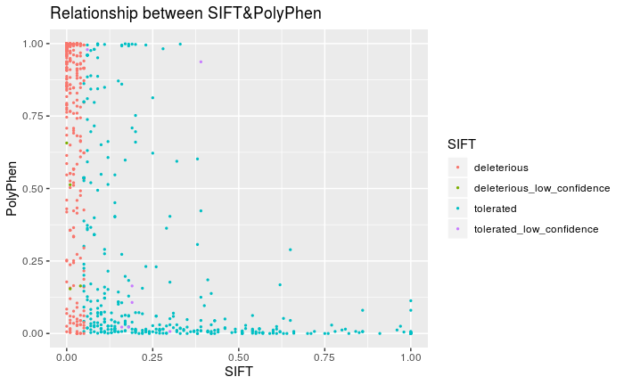

```r
d1 %>% ggplot(aes(as.numeric(sift_n), as.numeric(poly_n), col = sift_c)) + geom_point(size = 0.5) + labs(x='SIFT', y='PolyPhen', title = 'Relationship between SIFT&PolyPhen', color = "SIFT")
```

살펴본 결과 두가지 결과를 확인할 수 있었다.

1. sift가 deleterious할때 polyphen값은 전 영역에 걸쳐 분포한다.
2. 전체적으로 x축과 y축 근처에 많은 값들이 모여있다.

이 두가지에 대하서는 뒤에서 2-3에서 설명하였다.

#### 2-2. SIFT와 PolyPhen, MPC의 관계

MPC역시 SIFT, PolyPhen과 같은 측정방법의 일종이다. 그래서 2-1과 마찬가지로 이 셋 사이에도 관련성이 있을것이라 예상했다. 데이터 분석은 2-1과 동일하게 scatterplot을 그려보았다.

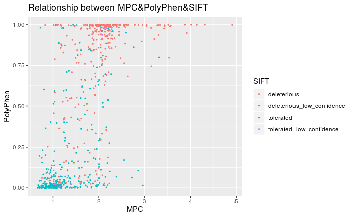

```r
d1 %>% ggplot(aes(as.numeric(as.character(MPC)), as.numeric(poly_n), col = sift_c)) + geom_point(size = 0.5) + labs(x='MPC', y='PolyPhen', title = 'Relationship between MPC&PolyPhen&SIFT', color = "SIFT")
```

두가지 사실을 확인할 수 있다.

1. mpc가 커질수록 polyphen의 damaging의 비율이 높아진다.
2. sift역시 mpc의 값이 커질수록 deleterious로 값이 치우친다.

1. MPC, sift, polyphen 사이에 연관관계가 존재하지만, 매우 명확하지는 않다.
2. 대부분의 값들이 x축의 왼쪽부근과 y축의 위쪽부근, 즉 저위험군과 고위험군에 쏠려있다

는 사실을 볼 수 있다.

#### 2-3. 의문 탐구

2-1과 2-2에서 나는 두가지 의문점을 가졌다.

1. sift, polyphen, MPC사이의 상관관계가 완벽하게 명확치는 않다.
2. 데이터값들은 연속적으로 고르게 분포한게 아니라 저위험군과 고위험군 양 극단에 쏠려 분포한다. 이 밀집집단들이 의미하는 것은 무엇인가?

먼저 첫번째 의문점에 대해 생각해보았다. sift, polyphen, MPC는 모두 유전자의 염기서열의 변화가 어떻게 표현형에 미치는지를 측정한다. 그러므로 같은 변이에 대해 세 방식으로 각각 측정한다면 그 값들이 어느정도 유사성을 띌 수 밖에 없다. 다만, 세 측정법의 접근방식에는 차이가 있을 것이고, 이때문에 때때로 각 측정값들이 예측하는 위험성 정도에 차이가 발생할 것이다. 또한 실험과정에서 자연스럽게 발생하는 측정이나 기기오류등도 영향을 끼칠 수 있을 것이다. 이때문에 상관관계게 명확지는 않은 것이다.

두번째는 그 의미를 생각해보았다. 저위험군군은 변이가 표현형에 심각한 damage를 끼치지 않은 일반인, 고위험군은 변이가 표현에 심각하게 영향을 끼친 환자라고 볼 수도 있지 않을까? 그래서 아래의 관련 데이터를 이용하여 정말 저 두 밀집그룹이 환자와 일반인인지 확인해보았다.

```r
p = read.csv('https://www.dropbox.com/s/he7r6v4hxu0ibno/tableS1.Sanders2018.txt?dl=1', sep='\t')
print(p)
```

| PatientID | PatientSex | PatientAgeAtAssessment | Chr | Pos_hg19 | Ref | Alt | Type | Effect | c.DNA | p.Protein | Inheritence | Source | SourcePMID | Ben.Shalom2017 | Wolff2017 | AnyRecurrence | UniqueSample.Family | TrueRecurrence | Seizures | SeizureOnsetDays | SeizureType | ASD | DD.ID | DD.ID.severity | OtherFeatures | Classification |
| --- | --- | --- | --- | --- | --- | --- | --- | --- | --- | --- | --- | --- | --- | --- | --- | --- | --- | --- | --- | --- | --- | --- | --- | --- | --- | --- |
| 14525.p1 | M | 11y | 2 | 166152367 | G | A | SNV | Missense | c.34G>A | p.D12N | DeNovo | SSC Iossifov et al 2014 | 25363768 | Y | N | 1 | Y | 1 | Y | 912 | Unknown | Y | Y | Severe | . | ASD/DD |
| 2-1291-03 | M | >8y | 2 | 166152415 | C | T | SNV | Missense | c.82C>T | p.R28C | Inherited | Jiang et al 2013 | 23849776 | Y | N | 1 | Y | 1 | N | . | None | Y | N | . | . | ASD/DD |
| 8 | . | 3y | 2 | 166152439 | A | G | SNV | Missense | c.106A>G | p.R36G | Maternal | Wolff et al. 2017 | 28379373 | N | Y | 3 | Y | 1 | Y | 480 | F (cluster) | N | N | . | . | BIS |
| 9 | . | 5y | 2 | 166152439 | A | G | SNV | Missense | c.106A>G | p.R36G | Maternal | Wolff et al. 2017 | 28379373 | N | Y | 3 | N | 1 | Y | 690 | F, C | N | N | . | . | BIS |
| 15467.x1 | F | . | 2 | 166152439 | A | G | SNV | Missense | c.106A>G | p.R36G | Inherited | Simons_VIP | . | Y | N | 3 | ? | 1 | Y | 730 | Unknown | Unknown | N | . | . | Unclear |
| SKLMG_M12434 | . | . | 2 | 166152561 | G | CCC | Indel | Frameshift | c.228G>CCC | p.V76fs | DeNovo | Stressman et al 2017 | 28191889 | Y | N | 1 | Y | 1 | Unknown | . | . | Y | Unknown | . | . | ASD/DD |
| ASDFI_732 | M | >2y | 2 | 166152578 | A | G | SNV | Missense | c.245A>G | p.D82G | DeNovo | ASC De Rubeis et al 2014 | 25363760 | Y | N | 1 | Y | 1 | Unknown | . | . | Y | Unknown | . | . | ASD/DD |
| OMIM.0008 | F | 29y | 2 | 166153563 | C | T | SNV | Nonsense | c.304C>T | p.R102X | DeNovo | Kamiya et al 2004 | 15028761 | Y | Y | 2 | Y | 1 | Y | 547 | A, AA | Y | Y | Severe | hyperkinetic | ASD/DD |
| DDD4K.03614 | F | . | 2 | 166153563 | C | T | SNV | Nonsense | c.304C>T | p.R102X | DeNovo | DDD 2015; DDD 2017 | 25533962; 28135719 | Y | N | 2 | N | 1 | Unknown | . | . | Unknown | Y | Unknown | . | ASD/DD |
| PatientC | F | 3y | 2 | 166164367 | T | A | SNV | Missense | c.396T>A | p.N132K | DeNovo | Matalon et al 2014 | 24659627 | Y | Y | 1 | Y | 1 | Y | 1 | TC | Unknown | Y | Severe | hypotonia | IEE |

[output cut: 253 more lines]

새로운 데이터 p는 SCN2A에 문제를 가진 환자들의 데이터이다. 즉, 이 데이터의 variant 정보(Chr, Pos_hg19, Ref, Alt)와 일치하는 d1의 데이터는 환자로, 아니면 일반인으로 구분할 수 있을 것이다.

d1의 variant 정보가 p에 존재하면 ‘patient’, 그렇지 않으면 ’normal’값을 지정하는 새로운 column ’disease’를 d1에 추가한다.

```r
p <- p %>% unite(., col = disease, Chr, Pos_hg19, Ref, Alt, sep = ':', remove=TRUE)
disease<- dplyr::pull(p, disease)

d1 <- ifelse(d1$Variant %in% disease, print('patient'), print('normal')) %>% mutate(d1, disease = .)
```

```
[1] "patient"
[1] "normal"
```

이제 앞서 만들었던 graph를 ‘disease’ column별로 색을 칠해보았다.

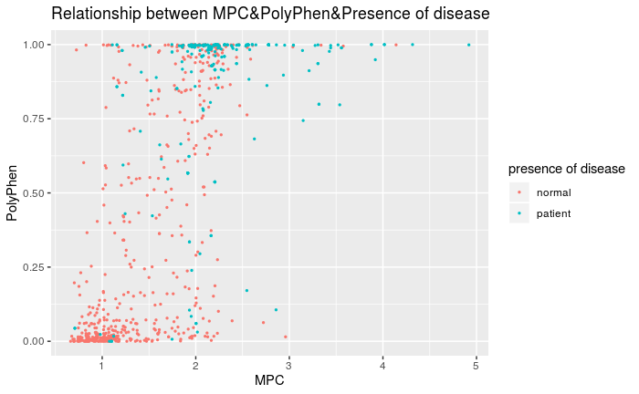

예상했던 것처럼 상단 고위험군은 patient, 좌측 하단 저위험군은 일반인인 normal 집단을 의미하는 것이었다.

PolyPhen, SIFT와 disease여부사이의 관계를 쉽게 판단하는 그래프도 그려보았다.

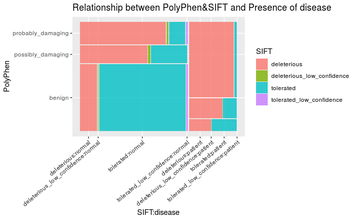

```r
install.packages("ggmosaic")
library(ggmosaic)
d1 %>% ggplot() + geom_mosaic(aes(x = product(poly_c, disease), fill = sift_c)) +  theme(axis.text.x = element_text(angle = 40, hjust = 1)) + labs(title = "Relationship between PolyPhen&SIFT and Presence of disease", fill = "SIFT", x="SIFT:disease", y = "PolyPhen")
```

좌측 normal 집단은 beningn이면서 tolerated한 범위가 가장 크지만, 우측 patient집단은 probably damaing이면서 deleterious한 부분이 가장 크다는 것을 한 눈에 볼 수 있다.

# 3. MPC와 gnomAD_AF의 관계

#### 3-1. data 정리

gnomAD_AF에 있는 NA는 정확한 의미를 알 수 없으므로 제외한 새로운 dataframe d2를 생성하도록 하겠다.

```r
d2 <- d1 %>% filter(!is.na(gnomAD_AF))
```

#### 3-2. MPC와 gnomAD_AF 비교

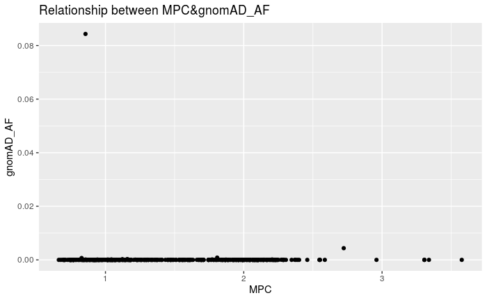

```r
d2 %>% ggplot(aes(as.numeric(as.character(MPC)), as.numeric(gnomAD_AF)))+ geom_point() +  labs(title = 'Relationship between MPC&gnomAD_AF', x= 'MPC', y = 'gnomAD_AF')
```

위의 그래프는 제대로 된 값을 보여주지 못한다. 그 이유는 아마 gnomAD_AF의 값이 0.08쯤으로 확인되는 outlier때문일것이다.

그래서 gnomAD_AF의 outlier를 제거한 값만 그래프에 사용하기로 했다. 그런데 어떻게 outliner를 정의할 것인가? 만약 gnomAD_AF가 정규분포형태에 가깝다면 Turkey’s definition을 쓸 수 있을 것이다. 그래서 우선gnomAD_AF의 분포를 qqplot을 사용하여 파악해보기로 했다. (단, m은 너무 큰 값의 outliner가 있으므로 average대신 median을 사용하였고, sd는 mad를 사용하기로 했다.)

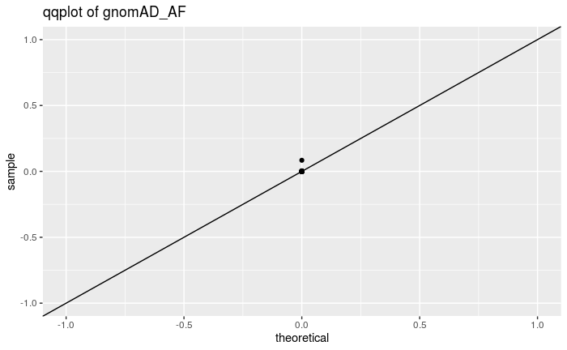

```r
params <- d2 %>% summarize(mean = median(d2$gnomAD_AF), sd = mad(d2$gnomAD_AF))

d2 %>% ggplot(aes(sample = gnomAD_AF)) +  geom_qq(dparams = params) + geom_abline() + scale_y_continuous(limits=c(-1, 1)) + scale_x_continuous(limits=c(-1, 1)) + labs(title = 'qqplot of gnomAD_AF')
```

이 그래프가 의미하는 것은 무엇일까? sampel, 즉 geomAD_AF의 값이 정규분포처럼 연속적으로 배치된 것이 아니라 특정 값의 빈도가 매우 높은, 일종의 category형식이라고 추측하였다. 그래서 count 함수를 이용하여 gnomAD_AF을 파악해보았다.

```r
d2 %>% count(gnomAD_AF)
```

| gnomAD_AF | n |
| --- | --- |
| 3.976e-06 | 7 |
| 3.977e-06 | 23 |
| 3.978e-06 | 36 |
| 3.979e-06 | 24 |
| 3.980e-06 | 34 |
| 3.981e-06 | 20 |
| 3.982e-06 | 12 |
| 3.983e-06 | 14 |
| 3.984e-06 | 6 |
| 3.985e-06 | 18 |

[output cut: 153 more lines]

역시 일부 값에 많은 element들이 모여있었다. 그렇다면 어떻게 outliner를 결정해야 할까? 우선 gnomAD_AF를 그 크기에 따라 정렬해보았다.

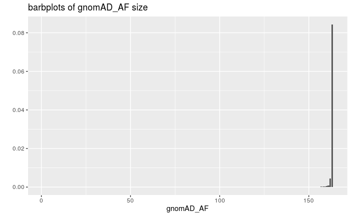

```r
tab1 <- d2 %>% count(gnomAD_AF) %>% arrange(gnomAD_AF) %>% mutate(rank = c(1:163))


tab1 %>% ggplot(aes(rank, gnomAD_AF)) + geom_bar(stat = 'identity') + labs(title = 'barbplots of gnomAD_AF size', x = 'gnomAD_AF', y = "")
```

그래프를 통해 대부분의 gnomAD_AF는 거의 0에 수렴하는 반면 일부만이 매우 높은 값을 가지고 있다는 것을 알 수 있다. 그래서 우선 고민끝에 quantile을 사용하여 95%까지의 probability의gnomAD_AF 포함하는 그래프를 그려보기로 했다.

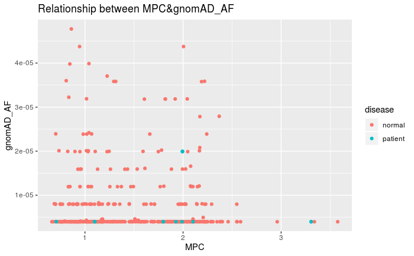

```r
d2 %>% filter(gnomAD_AF <= quantile(gnomAD_AF, 0.95)) %>% ggplot(aes(as.numeric(as.character(MPC)), as.numeric(gnomAD_AF), col = disease)) + geom_point() + labs(title = 'Relationship between MPC&gnomAD_AF', x= 'MPC', y = 'gnomAD_AF')
```

그래프를 보니 MPC와 gnomAD_AF사이에 별다른 관련성은 찾아볼 수 없다. 즉, gnomAD_AF는 variant의 표현형에 대한 effect정도와는 별 관련이 없는 독자적인 수치이다.

# 4. exon과 다른 variable의 관계

exon과 MPC, SIFT, PolyPhen, disease column들의 관계를 비교해보고 싶었다.

#### 4.1 exon과 MPC,PolyPhen, SIFT 비교

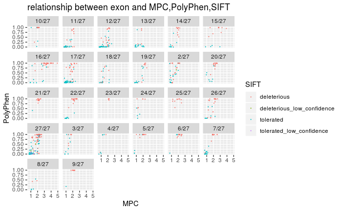

```r
d1 %>% ggplot(aes(as.numeric(as.character(MPC)), as.numeric(poly_n), col = sift_c)) + geom_point(size = 0.1) + facet_wrap(~EXON) + labs(title = 'relationship between exon and MPC,PolyPhen,SIFT', x= 'MPC', y = 'PolyPhen', color = 'SIFT')
```

그래프를 통해 한눈에 exon에 따른 SIFT, MPC, PolyPhen의 분포를 알 수 있다. 그런데 여기에 더해 병의 여부를 나타내는 disease column의 분포도 추가하고 싶었다.

```r
print(d3$danger)
```

```
  [1] "deleterious_low_confidence" "deleterious_low_confidence" "deleterious"
  [4] "deleterious"                "deleterious"                "tolerated"
  [7] "tolerated"                  "tolerated"                  "tolerated"
 [10] "tolerated"                  "deleterious"                "deleterious"
 [13] "tolerated"                  "deleterious"                "deleterious"
 [16] "deleterious"                "patient"                    "deleterious"
 [19] "tolerated"                  "deleterious"                "patient"
 [22] "tolerated"                  "tolerated"                  "tolerated"
 [25] "tolerated"                  "tolerated"                  "tolerated"
 [28] "tolerated"                  "tolerated"                  "tolerated"
 [31] "tolerated"                  "deleterious"                "deleterious"
 [34] "tolerated"                  "tolerated"                  "tolerated"
 [37] "tolerated"                  "deleterious"                "deleterious"
 [40] "deleterious"                "tolerated"                  "deleterious"
 [43] "tolerated"                  "deleterious"                "deleterious"
```

[output cut: 242 more lines]

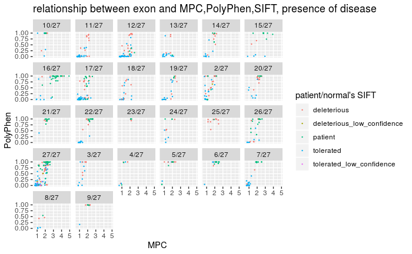

```r
d3 %>% ggplot(aes(as.numeric(as.character(MPC)), as.numeric(poly_n), col = danger)) + geom_point(size = 0.2) + facet_wrap(~EXON) + labs(title = 'relationship between exon and MPC,PolyPhen,SIFT, presence of disease', color = "patient/normal's SIFT", x='MPC', y='PolyPhen')
```

이 그래프를 통해 알 수 있는 것은

1. 모든 exon에서 SIFT, MPC, PolyPhen의 상관관계는 유효하게 적용된다.
2. EXON별로 존재하는 variant수가 차이가 있다.
3. EXON별로 해당 variant들의 표현형에 대한 effect의 정도(patient의 비율)에는 차이가 있다.

# 5. 결론

위의 결과들을 바탕으로 data 분석 전 세웠던 탐구주제에 대해 모두 결론을 내릴 수 있게 되었다.

**1. variant의 표현형에 대한 effect와 관련된 column간의 상관관계 유무 탐구**

상관관계가 존재한다. MPC, PolyPhen, SIFT는 모두 연관되어 있으며, MPC,PolyPhen 수치는 비례, 그리고 이 둘과 SIFT의 수치는 반비례하는 관계를 가진다.

**2. 1의 column들과 exon과의 관계 탐구**

이는 4-1의 최종 그래프로 설명을 할 수 있다.

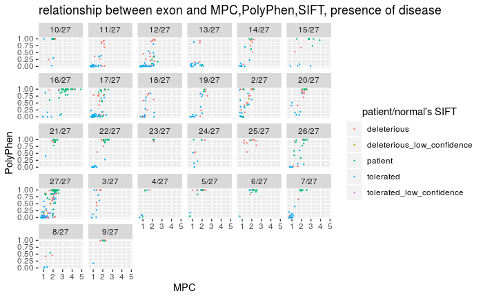

```r
d3 %>% ggplot(aes(as.numeric(as.character(MPC)), as.numeric(poly_n), col = danger)) + geom_point(size = 0.2) + facet_wrap(~EXON) + labs(title = 'relationship between exon and MPC,PolyPhen,SIFT, presence of disease', color = "patient/normal's SIFT", x='MPC', y='PolyPhen') + guides(colour = guide_legend(title.hjust = 0.5))
```

SIFT: deleterious(patient)의 점과 toerated점의 비율이 각 exon마다 다르다. ex)21, 25번은 deleterious(patient)의 비율이 높은 반면 11번은 tolerated의 비율이 높다.

PolyPhen: 값의 분포가 각 exon마다 다르다. ex) 27, 7은 저위험군이 많은 반면 6, 16번은 고위험군이 많다.

이를 통해 각 exon별로 variant impact to phenomenon에 차이가 있다고 볼 수 있다. 단, 이것은 각 exon의 특이성과 같은 것이지, exon의 번호에 다른 순차적인 연관성은 아니다.

아래는 기존의 탐구주제 외에 데이터를 분석하며 부수적으로 찾은 내용이다.

**추가1.variant 확률(gnomAD_AF)는 표현형에 대한 영향(MPC)와는 차이가 없다.**

**추가2. variant들은 exon에 걸쳐 그 수가 고르게 분포하지 않는다**